# Analyzing the Effect of Pit Stop Time Duration on Race Results

### Group 1: Sydney Walker, Alana Dawson, Ishana Ram, Deborah Hong

#### QTM 151 - Alejandro Sanchez Becerra

#### April 25th, 2023

### Importing Libraries

```python
import pandas as pd
import matplotlib.pyplot as plt
import matplotlib.dates as mdates
from datetime import date, time, datetime
import numpy as np
import statsmodels.api as sm
import statsmodels.formula.api as smf
from statsmodels.iolib.summary2 import summary_col
```

```python
pitstops = pd.read_csv("data_raw/pit_stops.csv")
drivers = pd.read_csv("data_raw/drivers.csv")
results = pd.read_csv("data_raw/results.csv")
races = pd.read_csv("data_raw/races.csv")

display()
```

```python
#British Grand Prix
races_British_grandprix = races.query('name == "British Grand Prix"')
races_British_grandprix.sort_values("year", ascending = True)
display(races_British_grandprix)

#Itlian Grand Prix
races_Australian_grandprix = races.query('name == "Australian Grand Prix"')
races_Australian_grandprix.sort_values("year", ascending = True)
display(races_Australian_grandprix)
```

|  | raceId | year | round | circuitId | name | date | time | url | fp1_date | fp1_time | fp2_date | fp2_time | fp3_date | fp3_time | quali_date | quali_time | sprint_date | sprint_time |
| --- | --- | --- | --- | --- | --- | --- | --- | --- | --- | --- | --- | --- | --- | --- | --- | --- | --- | --- |
| 7 | 8 | 2009 | 8 | 9 | British Grand Prix | 2009-06-21 | 12:00:00 | http://en.wikipedia.org/wiki/2009_British_Gran... | \N | \N | \N | \N | \N | \N | \N | \N | \N | \N |
| 25 | 26 | 2008 | 9 | 9 | British Grand Prix | 2008-07-06 | 12:00:00 | http://en.wikipedia.org/wiki/2008_British_Gran... | \N | \N | \N | \N | \N | \N | \N | \N | \N | \N |
| 43 | 44 | 2007 | 9 | 9 | British Grand Prix | 2007-07-08 | 12:00:00 | http://en.wikipedia.org/wiki/2007_British_Gran... | \N | \N | \N | \N | \N | \N | \N | \N | \N | \N |
| 59 | 60 | 2006 | 8 | 9 | British Grand Prix | 2006-06-11 | 12:00:00 | http://en.wikipedia.org/wiki/2006_British_Gran... | \N | \N | \N | \N | \N | \N | \N | \N | \N | \N |
| 80 | 81 | 2005 | 11 | 9 | British Grand Prix | 2005-07-10 | 14:00:00 | http://en.wikipedia.org/wiki/2005_British_Gran... | \N | \N | \N | \N | \N | \N | \N | \N | \N | \N |
| ... | ... | ... | ... | ... | ... | ... | ... | ... | ... | ... | ... | ... | ... | ... | ... | ... | ... | ... |
| 1006 | 1019 | 2019 | 10 | 9 | British Grand Prix | 2019-07-14 | 13:10:00 | http://en.wikipedia.org/wiki/2019_British_Gran... | \N | \N | \N | \N | \N | \N | \N | \N | \N | \N |
| 1021 | 1034 | 2020 | 4 | 9 | British Grand Prix | 2020-08-02 | 13:10:00 | http://en.wikipedia.org/wiki/2020_British_Gran... | \N | \N | \N | \N | \N | \N | \N | \N | \N | \N |
| 1046 | 1061 | 2021 | 10 | 9 | British Grand Prix | 2021-07-18 | 14:00:00 | http://en.wikipedia.org/wiki/2021_British_Gran... | 2021-07-16 | \N | 2021-07-17 | \N | \N | \N | 2021-07-16 | \N | 2021-07-17 | \N |
| 1066 | 1083 | 2022 | 10 | 9 | British Grand Prix | 2022-07-03 | 14:00:00 | http://en.wikipedia.org/wiki/2022_British_Gran... | 2022-07-01 | 12:00:00 | 2022-07-01 | 15:00:00 | 2022-07-02 | 11:00:00 | 2022-07-02 | 14:00:00 | \N | \N |
| 1089 | 1108 | 2023 | 11 | 9 | British Grand Prix | 2023-07-09 | 14:00:00 | https://en.wikipedia.org/wiki/2023_British_Gra... | 2023-07-07 | 11:30:00 | 2023-07-07 | 15:00:00 | 2023-07-08 | 10:30:00 | 2023-07-08 | 14:00:00 | \N | \N |

74 rows × 18 columns

|  | raceId | year | round | circuitId | name | date | time | url | fp1_date | fp1_time | fp2_date | fp2_time | fp3_date | fp3_time | quali_date | quali_time | sprint_date | sprint_time |
| --- | --- | --- | --- | --- | --- | --- | --- | --- | --- | --- | --- | --- | --- | --- | --- | --- | --- | --- |
| 0 | 1 | 2009 | 1 | 1 | Australian Grand Prix | 2009-03-29 | 06:00:00 | http://en.wikipedia.org/wiki/2009_Australian_G... | \N | \N | \N | \N | \N | \N | \N | \N | \N | \N |
| 17 | 18 | 2008 | 1 | 1 | Australian Grand Prix | 2008-03-16 | 04:30:00 | http://en.wikipedia.org/wiki/2008_Australian_G... | \N | \N | \N | \N | \N | \N | \N | \N | \N | \N |
| 35 | 36 | 2007 | 1 | 1 | Australian Grand Prix | 2007-03-18 | 03:00:00 | http://en.wikipedia.org/wiki/2007_Australian_G... | \N | \N | \N | \N | \N | \N | \N | \N | \N | \N |
| 54 | 55 | 2006 | 3 | 1 | Australian Grand Prix | 2006-04-02 | 14:00:00 | http://en.wikipedia.org/wiki/2006_Australian_G... | \N | \N | \N | \N | \N | \N | \N | \N | \N | \N |
| 70 | 71 | 2005 | 1 | 1 | Australian Grand Prix | 2005-03-06 | 14:00:00 | http://en.wikipedia.org/wiki/2005_Australian_G... | \N | \N | \N | \N | \N | \N | \N | \N | \N | \N |
| 89 | 90 | 2004 | 1 | 1 | Australian Grand Prix | 2004-03-07 | \N | http://en.wikipedia.org/wiki/2004_Australian_G... | \N | \N | \N | \N | \N | \N | \N | \N | \N | \N |
| 107 | 108 | 2003 | 1 | 1 | Australian Grand Prix | 2003-03-09 | \N | http://en.wikipedia.org/wiki/2003_Australian_G... | \N | \N | \N | \N | \N | \N | \N | \N | \N | \N |
| 123 | 124 | 2002 | 1 | 1 | Australian Grand Prix | 2002-03-03 | \N | http://en.wikipedia.org/wiki/2002_Australian_G... | \N | \N | \N | \N | \N | \N | \N | \N | \N | \N |
| 140 | 141 | 2001 | 1 | 1 | Australian Grand Prix | 2001-03-04 | \N | http://en.wikipedia.org/wiki/2001_Australian_G... | \N | \N | \N | \N | \N | \N | \N | \N | \N | \N |
| 157 | 158 | 2000 | 1 | 1 | Australian Grand Prix | 2000-03-12 | \N | http://en.wikipedia.org/wiki/2000_Australian_G... | \N | \N | \N | \N | \N | \N | \N | \N | \N | \N |
| 174 | 175 | 1999 | 1 | 1 | Australian Grand Prix | 1999-03-07 | \N | http://en.wikipedia.org/wiki/1999_Australian_G... | \N | \N | \N | \N | \N | \N | \N | \N | \N | \N |
| 190 | 191 | 1998 | 1 | 1 | Australian Grand Prix | 1998-03-08 | \N | http://en.wikipedia.org/wiki/1998_Australian_G... | \N | \N | \N | \N | \N | \N | \N | \N | \N | \N |
| 206 | 207 | 1997 | 1 | 1 | Australian Grand Prix | 1997-03-09 | \N | http://en.wikipedia.org/wiki/1997_Australian_G... | \N | \N | \N | \N | \N | \N | \N | \N | \N | \N |
| 223 | 224 | 1996 | 1 | 1 | Australian Grand Prix | 1996-03-10 | \N | http://en.wikipedia.org/wiki/1996_Australian_G... | \N | \N | \N | \N | \N | \N | \N | \N | \N | \N |
| 255 | 256 | 1995 | 17 | 29 | Australian Grand Prix | 1995-11-12 | \N | http://en.wikipedia.org/wiki/1995_Australian_G... | \N | \N | \N | \N | \N | \N | \N | \N | \N | \N |
| 271 | 272 | 1994 | 16 | 29 | Australian Grand Prix | 1994-11-13 | \N | http://en.wikipedia.org/wiki/1994_Australian_G... | \N | \N | \N | \N | \N | \N | \N | \N | \N | \N |
| 287 | 288 | 1993 | 16 | 29 | Australian Grand Prix | 1993-11-07 | \N | http://en.wikipedia.org/wiki/1993_Australian_G... | \N | \N | \N | \N | \N | \N | \N | \N | \N | \N |
| 303 | 304 | 1992 | 16 | 29 | Australian Grand Prix | 1992-11-08 | \N | http://en.wikipedia.org/wiki/1992_Australian_G... | \N | \N | \N | \N | \N | \N | \N | \N | \N | \N |
| 319 | 320 | 1991 | 16 | 29 | Australian Grand Prix | 1991-11-03 | \N | http://en.wikipedia.org/wiki/1991_Australian_G... | \N | \N | \N | \N | \N | \N | \N | \N | \N | \N |
| 335 | 336 | 1990 | 16 | 29 | Australian Grand Prix | 1990-11-04 | \N | http://en.wikipedia.org/wiki/1990_Australian_G... | \N | \N | \N | \N | \N | \N | \N | \N | \N | \N |
| 337 | 338 | 2010 | 2 | 1 | Australian Grand Prix | 2010-03-28 | 06:00:00 | http://en.wikipedia.org/wiki/2010_Australian_G... | \N | \N | \N | \N | \N | \N | \N | \N | \N | \N |
| 370 | 371 | 1989 | 16 | 29 | Australian Grand Prix | 1989-11-05 | \N | http://en.wikipedia.org/wiki/1989_Australian_G... | \N | \N | \N | \N | \N | \N | \N | \N | \N | \N |
| 386 | 387 | 1988 | 16 | 29 | Australian Grand Prix | 1988-11-13 | \N | http://en.wikipedia.org/wiki/1988_Australian_G... | \N | \N | \N | \N | \N | \N | \N | \N | \N | \N |
| 402 | 403 | 1987 | 16 | 29 | Australian Grand Prix | 1987-11-15 | \N | http://en.wikipedia.org/wiki/1987_Australian_G... | \N | \N | \N | \N | \N | \N | \N | \N | \N | \N |
| 418 | 419 | 1986 | 16 | 29 | Australian Grand Prix | 1986-10-26 | \N | http://en.wikipedia.org/wiki/1986_Australian_G... | \N | \N | \N | \N | \N | \N | \N | \N | \N | \N |
| 434 | 435 | 1985 | 16 | 29 | Australian Grand Prix | 1985-11-03 | \N | http://en.wikipedia.org/wiki/1985_Australian_G... | \N | \N | \N | \N | \N | \N | \N | \N | \N | \N |
| 839 | 841 | 2011 | 1 | 1 | Australian Grand Prix | 2011-03-27 | 06:00:00 | http://en.wikipedia.org/wiki/2011_Australian_G... | \N | \N | \N | \N | \N | \N | \N | \N | \N | \N |
| 858 | 860 | 2012 | 1 | 1 | Australian Grand Prix | 2012-03-18 | 06:00:00 | http://en.wikipedia.org/wiki/2012_Australian_G... | \N | \N | \N | \N | \N | \N | \N | \N | \N | \N |
| 878 | 880 | 2013 | 1 | 1 | Australian Grand Prix | 2013-03-17 | 06:00:00 | http://en.wikipedia.org/wiki/2013_Australian_G... | \N | \N | \N | \N | \N | \N | \N | \N | \N | \N |
| 897 | 900 | 2014 | 1 | 1 | Australian Grand Prix | 2014-03-16 | 06:00:00 | http://en.wikipedia.org/wiki/2014_Australian_G... | \N | \N | \N | \N | \N | \N | \N | \N | \N | \N |
| 921 | 926 | 2015 | 1 | 1 | Australian Grand Prix | 2015-03-15 | 05:00:00 | http://en.wikipedia.org/wiki/2015_Australian_G... | \N | \N | \N | \N | \N | \N | \N | \N | \N | \N |
| 935 | 948 | 2016 | 1 | 1 | Australian Grand Prix | 2016-03-20 | 05:00:00 | http://en.wikipedia.org/wiki/2016_Australian_G... | \N | \N | \N | \N | \N | \N | \N | \N | \N | \N |
| 956 | 969 | 2017 | 1 | 1 | Australian Grand Prix | 2017-03-26 | 05:00:00 | http://en.wikipedia.org/wiki/2017_Australian_G... | \N | \N | \N | \N | \N | \N | \N | \N | \N | \N |
| 976 | 989 | 2018 | 1 | 1 | Australian Grand Prix | 2018-03-25 | 05:10:00 | http://en.wikipedia.org/wiki/2018_Australian_G... | \N | \N | \N | \N | \N | \N | \N | \N | \N | \N |
| 997 | 1010 | 2019 | 1 | 1 | Australian Grand Prix | 2019-03-17 | 05:10:00 | http://en.wikipedia.org/wiki/2019_Australian_G... | \N | \N | \N | \N | \N | \N | \N | \N | \N | \N |
| 1059 | 1076 | 2022 | 3 | 1 | Australian Grand Prix | 2022-04-10 | 05:00:00 | http://en.wikipedia.org/wiki/2022_Australian_G... | 2022-04-08 | 03:00:00 | 2022-04-08 | 06:00:00 | 2022-04-09 | 03:00:00 | 2022-04-09 | 06:00:00 | \N | \N |
| 1081 | 1100 | 2023 | 3 | 1 | Australian Grand Prix | 2023-04-02 | 05:00:00 | https://en.wikipedia.org/wiki/2023_Australian_... | 2023-03-31 | 01:30:00 | 2023-03-31 | 05:00:00 | 2023-04-01 | 01:30:00 | 2023-04-01 | 05:00:00 | \N | \N |

```python
#British Grand Prix
sorted_pitstops_British = pitstops.sort_values(by='duration', ascending=False)
pitstops_merge_British = pd.merge(races_British_grandprix,
                          sorted_pitstops_British,
                          on = "raceId",
                          how = "left")
British_grandprix_2011 = (pitstops_merge_British[pitstops_merge_British['year'] == 2011])
display(British_grandprix_2011)

#Australian Grand Prix
sorted_pitstops_Australian = pitstops.sort_values(by='duration', ascending=False)
pitstops_merge_Australian = pd.merge(races_Australian_grandprix,
                          sorted_pitstops_Australian,
                          on = "raceId",
                          how = "left")
Australian_grandprix_2011 = (pitstops_merge_Australian[pitstops_merge_Australian['year'] == 2011])
display(Australian_grandprix_2011)
```

|  | raceId | year | round | circuitId | name | date | time_x | url | fp1_date | fp1_time | ... | quali_date | quali_time | sprint_date | sprint_time | driverId | stop | lap | time_y | duration | milliseconds |
| --- | --- | --- | --- | --- | --- | --- | --- | --- | --- | --- | --- | --- | --- | --- | --- | --- | --- | --- | --- | --- | --- |
| 61 | 849 | 2011 | 9 | 9 | British Grand Prix | 2011-07-10 | 12:00:00 | http://en.wikipedia.org/wiki/2011_British_Gran... | \N | \N | ... | \N | \N | \N | \N | 814.0 | 2.0 | 24.0 | 13:46:50 | 45.291 | 45291.0 |
| 62 | 849 | 2011 | 9 | 9 | British Grand Prix | 2011-07-10 | 12:00:00 | http://en.wikipedia.org/wiki/2011_British_Gran... | \N | \N | ... | \N | \N | \N | \N | 30.0 | 2.0 | 16.0 | 13:33:23 | 31.751 | 31751.0 |
| 63 | 849 | 2011 | 9 | 9 | British Grand Prix | 2011-07-10 | 12:00:00 | http://en.wikipedia.org/wiki/2011_British_Gran... | \N | \N | ... | \N | \N | \N | \N | 20.0 | 2.0 | 27.0 | 13:51:10 | 31.558 | 31558.0 |
| 64 | 849 | 2011 | 9 | 9 | British Grand Prix | 2011-07-10 | 12:00:00 | http://en.wikipedia.org/wiki/2011_British_Gran... | \N | \N | ... | \N | \N | \N | \N | 155.0 | 2.0 | 20.0 | 13:40:27 | 31.551 | 31551.0 |
| 65 | 849 | 2011 | 9 | 9 | British Grand Prix | 2011-07-10 | 12:00:00 | http://en.wikipedia.org/wiki/2011_British_Gran... | \N | \N | ... | \N | \N | \N | \N | 814.0 | 3.0 | 26.0 | 13:50:52 | 31.471 | 31471.0 |
| 66 | 849 | 2011 | 9 | 9 | British Grand Prix | 2011-07-10 | 12:00:00 | http://en.wikipedia.org/wiki/2011_British_Gran... | \N | \N | ... | \N | \N | \N | \N | 30.0 | 1.0 | 9.0 | 13:20:38 | 30.242 | 30242.0 |
| 67 | 849 | 2011 | 9 | 9 | British Grand Prix | 2011-07-10 | 12:00:00 | http://en.wikipedia.org/wiki/2011_British_Gran... | \N | \N | ... | \N | \N | \N | \N | 816.0 | 1.0 | 11.0 | 13:25:14 | 28.742 | 28742.0 |
| 68 | 849 | 2011 | 9 | 9 | British Grand Prix | 2011-07-10 | 12:00:00 | http://en.wikipedia.org/wiki/2011_British_Gran... | \N | \N | ... | \N | \N | \N | \N | 155.0 | 1.0 | 11.0 | 13:24:19 | 28.448 | 28448.0 |
| 69 | 849 | 2011 | 9 | 9 | British Grand Prix | 2011-07-10 | 12:00:00 | http://en.wikipedia.org/wiki/2011_British_Gran... | \N | \N | ... | \N | \N | \N | \N | 16.0 | 3.0 | 40.0 | 14:13:32 | 27.240 | 27240.0 |
| 70 | 849 | 2011 | 9 | 9 | British Grand Prix | 2011-07-10 | 12:00:00 | http://en.wikipedia.org/wiki/2011_British_Gran... | \N | \N | ... | \N | \N | \N | \N | 817.0 | 2.0 | 28.0 | 13:56:23 | 26.942 | 26942.0 |
| 71 | 849 | 2011 | 9 | 9 | British Grand Prix | 2011-07-10 | 12:00:00 | http://en.wikipedia.org/wiki/2011_British_Gran... | \N | \N | ... | \N | \N | \N | \N | 24.0 | 1.0 | 11.0 | 13:25:12 | 26.643 | 26643.0 |
| 72 | 849 | 2011 | 9 | 9 | British Grand Prix | 2011-07-10 | 12:00:00 | http://en.wikipedia.org/wiki/2011_British_Gran... | \N | \N | ... | \N | \N | \N | \N | 814.0 | 1.0 | 12.0 | 13:26:02 | 26.612 | 26612.0 |
| 73 | 849 | 2011 | 9 | 9 | British Grand Prix | 2011-07-10 | 12:00:00 | http://en.wikipedia.org/wiki/2011_British_Gran... | \N | \N | ... | \N | \N | \N | \N | 4.0 | 1.0 | 12.0 | 13:25:42 | 26.566 | 26566.0 |
| 74 | 849 | 2011 | 9 | 9 | British Grand Prix | 2011-07-10 | 12:00:00 | http://en.wikipedia.org/wiki/2011_British_Gran... | \N | \N | ... | \N | \N | \N | \N | 67.0 | 1.0 | 11.0 | 13:24:30 | 26.279 | 26279.0 |
| 75 | 849 | 2011 | 9 | 9 | British Grand Prix | 2011-07-10 | 12:00:00 | http://en.wikipedia.org/wiki/2011_British_Gran... | \N | \N | ... | \N | \N | \N | \N | 813.0 | 1.0 | 11.0 | 13:24:27 | 26.238 | 26238.0 |
| 76 | 849 | 2011 | 9 | 9 | British Grand Prix | 2011-07-10 | 12:00:00 | http://en.wikipedia.org/wiki/2011_British_Gran... | \N | \N | ... | \N | \N | \N | \N | 817.0 | 1.0 | 12.0 | 13:27:17 | 25.872 | 25872.0 |
| 77 | 849 | 2011 | 9 | 9 | British Grand Prix | 2011-07-10 | 12:00:00 | http://en.wikipedia.org/wiki/2011_British_Gran... | \N | \N | ... | \N | \N | \N | \N | 22.0 | 1.0 | 11.0 | 13:24:38 | 25.860 | 25860.0 |
| 78 | 849 | 2011 | 9 | 9 | British Grand Prix | 2011-07-10 | 12:00:00 | http://en.wikipedia.org/wiki/2011_British_Gran... | \N | \N | ... | \N | \N | \N | \N | 16.0 | 1.0 | 11.0 | 13:24:13 | 25.737 | 25737.0 |
| 79 | 849 | 2011 | 9 | 9 | British Grand Prix | 2011-07-10 | 12:00:00 | http://en.wikipedia.org/wiki/2011_British_Gran... | \N | \N | ... | \N | \N | \N | \N | 815.0 | 2.0 | 32.0 | 14:00:08 | 25.619 | 25619.0 |
| 80 | 849 | 2011 | 9 | 9 | British Grand Prix | 2011-07-10 | 12:00:00 | http://en.wikipedia.org/wiki/2011_British_Gran... | \N | \N | ... | \N | \N | \N | \N | 24.0 | 2.0 | 31.0 | 14:00:49 | 25.505 | 25505.0 |
| 81 | 849 | 2011 | 9 | 9 | British Grand Prix | 2011-07-10 | 12:00:00 | http://en.wikipedia.org/wiki/2011_British_Gran... | \N | \N | ... | \N | \N | \N | \N | 17.0 | 2.0 | 26.0 | 13:49:36 | 25.490 | 25490.0 |
| 82 | 849 | 2011 | 9 | 9 | British Grand Prix | 2011-07-10 | 12:00:00 | http://en.wikipedia.org/wiki/2011_British_Gran... | \N | \N | ... | \N | \N | \N | \N | 816.0 | 2.0 | 28.0 | 13:55:39 | 25.428 | 25428.0 |
| 83 | 849 | 2011 | 9 | 9 | British Grand Prix | 2011-07-10 | 12:00:00 | http://en.wikipedia.org/wiki/2011_British_Gran... | \N | \N | ... | \N | \N | \N | \N | 10.0 | 1.0 | 11.0 | 13:24:52 | 25.416 | 25416.0 |
| 84 | 849 | 2011 | 9 | 9 | British Grand Prix | 2011-07-10 | 12:00:00 | http://en.wikipedia.org/wiki/2011_British_Gran... | \N | \N | ... | \N | \N | \N | \N | 815.0 | 1.0 | 12.0 | 13:26:13 | 25.386 | 25386.0 |
| 85 | 849 | 2011 | 9 | 9 | British Grand Prix | 2011-07-10 | 12:00:00 | http://en.wikipedia.org/wiki/2011_British_Gran... | \N | \N | ... | \N | \N | \N | \N | 1.0 | 1.0 | 12.0 | 13:25:49 | 25.100 | 25100.0 |
| 86 | 849 | 2011 | 9 | 9 | British Grand Prix | 2011-07-10 | 12:00:00 | http://en.wikipedia.org/wiki/2011_British_Gran... | \N | \N | ... | \N | \N | \N | \N | 18.0 | 1.0 | 11.0 | 13:24:05 | 25.070 | 25070.0 |
| 87 | 849 | 2011 | 9 | 9 | British Grand Prix | 2011-07-10 | 12:00:00 | http://en.wikipedia.org/wiki/2011_British_Gran... | \N | \N | ... | \N | \N | \N | \N | 10.0 | 2.0 | 30.0 | 13:58:43 | 24.959 | 24959.0 |
| 88 | 849 | 2011 | 9 | 9 | British Grand Prix | 2011-07-10 | 12:00:00 | http://en.wikipedia.org/wiki/2011_British_Gran... | \N | \N | ... | \N | \N | \N | \N | 808.0 | 1.0 | 11.0 | 13:24:37 | 24.880 | 24880.0 |
| 89 | 849 | 2011 | 9 | 9 | British Grand Prix | 2011-07-10 | 12:00:00 | http://en.wikipedia.org/wiki/2011_British_Gran... | \N | \N | ... | \N | \N | \N | \N | 20.0 | 1.0 | 13.0 | 13:27:22 | 24.818 | 24818.0 |
| 90 | 849 | 2011 | 9 | 9 | British Grand Prix | 2011-07-10 | 12:00:00 | http://en.wikipedia.org/wiki/2011_British_Gran... | \N | \N | ... | \N | \N | \N | \N | 3.0 | 1.0 | 12.0 | 13:26:12 | 24.722 | 24722.0 |
| 91 | 849 | 2011 | 9 | 9 | British Grand Prix | 2011-07-10 | 12:00:00 | http://en.wikipedia.org/wiki/2011_British_Gran... | \N | \N | ... | \N | \N | \N | \N | 153.0 | 1.0 | 12.0 | 13:26:20 | 24.719 | 24719.0 |
| 92 | 849 | 2011 | 9 | 9 | British Grand Prix | 2011-07-10 | 12:00:00 | http://en.wikipedia.org/wiki/2011_British_Gran... | \N | \N | ... | \N | \N | \N | \N | 2.0 | 1.0 | 10.0 | 13:22:37 | 24.716 | 24716.0 |
| 93 | 849 | 2011 | 9 | 9 | British Grand Prix | 2011-07-10 | 12:00:00 | http://en.wikipedia.org/wiki/2011_British_Gran... | \N | \N | ... | \N | \N | \N | \N | 30.0 | 3.0 | 31.0 | 13:58:47 | 24.651 | 24651.0 |
| 94 | 849 | 2011 | 9 | 9 | British Grand Prix | 2011-07-10 | 12:00:00 | http://en.wikipedia.org/wiki/2011_British_Gran... | \N | \N | ... | \N | \N | \N | \N | 67.0 | 2.0 | 25.0 | 13:48:50 | 24.620 | 24620.0 |
| 95 | 849 | 2011 | 9 | 9 | British Grand Prix | 2011-07-10 | 12:00:00 | http://en.wikipedia.org/wiki/2011_British_Gran... | \N | \N | ... | \N | \N | \N | \N | 2.0 | 2.0 | 30.0 | 13:57:06 | 24.434 | 24434.0 |
| 96 | 849 | 2011 | 9 | 9 | British Grand Prix | 2011-07-10 | 12:00:00 | http://en.wikipedia.org/wiki/2011_British_Gran... | \N | \N | ... | \N | \N | \N | \N | 3.0 | 2.0 | 30.0 | 13:56:50 | 24.399 | 24399.0 |
| 97 | 849 | 2011 | 9 | 9 | British Grand Prix | 2011-07-10 | 12:00:00 | http://en.wikipedia.org/wiki/2011_British_Gran... | \N | \N | ... | \N | \N | \N | \N | 18.0 | 2.0 | 26.0 | 13:49:45 | 24.287 | 24287.0 |
| 98 | 849 | 2011 | 9 | 9 | British Grand Prix | 2011-07-10 | 12:00:00 | http://en.wikipedia.org/wiki/2011_British_Gran... | \N | \N | ... | \N | \N | \N | \N | 813.0 | 2.0 | 24.0 | 13:47:12 | 24.272 | 24272.0 |
| 99 | 849 | 2011 | 9 | 9 | British Grand Prix | 2011-07-10 | 12:00:00 | http://en.wikipedia.org/wiki/2011_British_Gran... | \N | \N | ... | \N | \N | \N | \N | 808.0 | 2.0 | 38.0 | 14:10:21 | 24.172 | 24172.0 |
| 100 | 849 | 2011 | 9 | 9 | British Grand Prix | 2011-07-10 | 12:00:00 | http://en.wikipedia.org/wiki/2011_British_Gran... | \N | \N | ... | \N | \N | \N | \N | 13.0 | 1.0 | 13.0 | 13:27:39 | 24.159 | 24159.0 |
| 101 | 849 | 2011 | 9 | 9 | British Grand Prix | 2011-07-10 | 12:00:00 | http://en.wikipedia.org/wiki/2011_British_Gran... | \N | \N | ... | \N | \N | \N | \N | 153.0 | 2.0 | 31.0 | 13:58:46 | 24.095 | 24095.0 |
| 102 | 849 | 2011 | 9 | 9 | British Grand Prix | 2011-07-10 | 12:00:00 | http://en.wikipedia.org/wiki/2011_British_Gran... | \N | \N | ... | \N | \N | \N | \N | 16.0 | 2.0 | 25.0 | 13:48:32 | 24.077 | 24077.0 |
| 103 | 849 | 2011 | 9 | 9 | British Grand Prix | 2011-07-10 | 12:00:00 | http://en.wikipedia.org/wiki/2011_British_Gran... | \N | \N | ... | \N | \N | \N | \N | 1.0 | 2.0 | 24.0 | 13:46:21 | 24.065 | 24065.0 |
| 104 | 849 | 2011 | 9 | 9 | British Grand Prix | 2011-07-10 | 12:00:00 | http://en.wikipedia.org/wiki/2011_British_Gran... | \N | \N | ... | \N | \N | \N | \N | 4.0 | 2.0 | 27.0 | 13:51:15 | 23.974 | 23974.0 |
| 105 | 849 | 2011 | 9 | 9 | British Grand Prix | 2011-07-10 | 12:00:00 | http://en.wikipedia.org/wiki/2011_British_Gran... | \N | \N | ... | \N | \N | \N | \N | 17.0 | 1.0 | 12.0 | 13:25:41 | 23.973 | 23973.0 |
| 106 | 849 | 2011 | 9 | 9 | British Grand Prix | 2011-07-10 | 12:00:00 | http://en.wikipedia.org/wiki/2011_British_Gran... | \N | \N | ... | \N | \N | \N | \N | 22.0 | 2.0 | 31.0 | 13:59:02 | 23.955 | 23955.0 |
| 107 | 849 | 2011 | 9 | 9 | British Grand Prix | 2011-07-10 | 12:00:00 | http://en.wikipedia.org/wiki/2011_British_Gran... | \N | \N | ... | \N | \N | \N | \N | 13.0 | 2.0 | 26.0 | 13:49:48 | 23.929 | 23929.0 |
| 108 | 849 | 2011 | 9 | 9 | British Grand Prix | 2011-07-10 | 12:00:00 | http://en.wikipedia.org/wiki/2011_British_Gran... | \N | \N | ... | \N | \N | \N | \N | 813.0 | 3.0 | 35.0 | 14:05:42 | 23.869 | 23869.0 |
| 109 | 849 | 2011 | 9 | 9 | British Grand Prix | 2011-07-10 | 12:00:00 | http://en.wikipedia.org/wiki/2011_British_Gran... | \N | \N | ... | \N | \N | \N | \N | 17.0 | 3.0 | 38.0 | 14:09:30 | 23.785 | 23785.0 |
| 110 | 849 | 2011 | 9 | 9 | British Grand Prix | 2011-07-10 | 12:00:00 | http://en.wikipedia.org/wiki/2011_British_Gran... | \N | \N | ... | \N | \N | \N | \N | 4.0 | 3.0 | 39.0 | 14:10:50 | 23.474 | 23474.0 |
| 111 | 849 | 2011 | 9 | 9 | British Grand Prix | 2011-07-10 | 12:00:00 | http://en.wikipedia.org/wiki/2011_British_Gran... | \N | \N | ... | \N | \N | \N | \N | 1.0 | 3.0 | 37.0 | 14:07:50 | 23.340 | 23340.0 |
| 112 | 849 | 2011 | 9 | 9 | British Grand Prix | 2011-07-10 | 12:00:00 | http://en.wikipedia.org/wiki/2011_British_Gran... | \N | \N | ... | \N | \N | \N | \N | 18.0 | 3.0 | 39.0 | 14:11:08 | 23.292 | 23292.0 |
| 113 | 849 | 2011 | 9 | 9 | British Grand Prix | 2011-07-10 | 12:00:00 | http://en.wikipedia.org/wiki/2011_British_Gran... | \N | \N | ... | \N | \N | \N | \N | 13.0 | 3.0 | 41.0 | 14:14:35 | 23.238 | 23238.0 |
| 114 | 849 | 2011 | 9 | 9 | British Grand Prix | 2011-07-10 | 12:00:00 | http://en.wikipedia.org/wiki/2011_British_Gran... | \N | \N | ... | \N | \N | \N | \N | 20.0 | 3.0 | 36.0 | 14:06:13 | 23.137 | 23137.0 |

54 rows × 24 columns

|  | raceId | year | round | circuitId | name | date | time_x | url | fp1_date | fp1_time | ... | quali_date | quali_time | sprint_date | sprint_time | driverId | stop | lap | time_y | duration | milliseconds |
| --- | --- | --- | --- | --- | --- | --- | --- | --- | --- | --- | --- | --- | --- | --- | --- | --- | --- | --- | --- | --- | --- |
| 26 | 841 | 2011 | 1 | 1 | Australian Grand Prix | 2011-03-27 | 06:00:00 | http://en.wikipedia.org/wiki/2011_Australian_G... | \N | \N | ... | \N | \N | \N | \N | 22.0 | 2.0 | 23.0 | 17:40:45 | 37.856 | 37856.0 |
| 27 | 841 | 2011 | 1 | 1 | Australian Grand Prix | 2011-03-27 | 06:00:00 | http://en.wikipedia.org/wiki/2011_Australian_G... | \N | \N | ... | \N | \N | \N | \N | 153.0 | 1.0 | 1.0 | 17:05:23 | 26.898 | 26898.0 |
| 28 | 841 | 2011 | 1 | 1 | Australian Grand Prix | 2011-03-27 | 06:00:00 | http://en.wikipedia.org/wiki/2011_Australian_G... | \N | \N | ... | \N | \N | \N | \N | 816.0 | 2.0 | 38.0 | 18:06:53 | 26.446 | 26446.0 |
| 29 | 841 | 2011 | 1 | 1 | Australian Grand Prix | 2011-03-27 | 06:00:00 | http://en.wikipedia.org/wiki/2011_Australian_G... | \N | \N | ... | \N | \N | \N | \N | 153.0 | 3.0 | 35.0 | 17:59:45 | 26.348 | 26348.0 |
| 30 | 841 | 2011 | 1 | 1 | Australian Grand Prix | 2011-03-27 | 06:00:00 | http://en.wikipedia.org/wiki/2011_Australian_G... | \N | \N | ... | \N | \N | \N | \N | 22.0 | 4.0 | 40.0 | 18:08:03 | 26.309 | 26309.0 |
| 31 | 841 | 2011 | 1 | 1 | Australian Grand Prix | 2011-03-27 | 06:00:00 | http://en.wikipedia.org/wiki/2011_Australian_G... | \N | \N | ... | \N | \N | \N | \N | 17.0 | 3.0 | 41.0 | 18:07:37 | 26.230 | 26230.0 |
| 32 | 841 | 2011 | 1 | 1 | Australian Grand Prix | 2011-03-27 | 06:00:00 | http://en.wikipedia.org/wiki/2011_Australian_G... | \N | \N | ... | \N | \N | \N | \N | 16.0 | 1.0 | 16.0 | 17:29:08 | 25.978 | 25978.0 |
| 33 | 841 | 2011 | 1 | 1 | Australian Grand Prix | 2011-03-27 | 06:00:00 | http://en.wikipedia.org/wiki/2011_Australian_G... | \N | \N | ... | \N | \N | \N | \N | 808.0 | 2.0 | 36.0 | 17:59:47 | 25.683 | 25683.0 |
| 34 | 841 | 2011 | 1 | 1 | Australian Grand Prix | 2011-03-27 | 06:00:00 | http://en.wikipedia.org/wiki/2011_Australian_G... | \N | \N | ... | \N | \N | \N | \N | 67.0 | 1.0 | 15.0 | 17:27:34 | 25.342 | 25342.0 |
| 35 | 841 | 2011 | 1 | 1 | Australian Grand Prix | 2011-03-27 | 06:00:00 | http://en.wikipedia.org/wiki/2011_Australian_G... | \N | \N | ... | \N | \N | \N | \N | 816.0 | 1.0 | 14.0 | 17:26:50 | 25.259 | 25259.0 |
| 36 | 841 | 2011 | 1 | 1 | Australian Grand Prix | 2011-03-27 | 06:00:00 | http://en.wikipedia.org/wiki/2011_Australian_G... | \N | \N | ... | \N | \N | \N | \N | 2.0 | 2.0 | 30.0 | 17:51:32 | 25.098 | 25098.0 |
| 37 | 841 | 2011 | 1 | 1 | Australian Grand Prix | 2011-03-27 | 06:00:00 | http://en.wikipedia.org/wiki/2011_Australian_G... | \N | \N | ... | \N | \N | \N | \N | 30.0 | 1.0 | 1.0 | 17:05:52 | 25.021 | 25021.0 |
| 38 | 841 | 2011 | 1 | 1 | Australian Grand Prix | 2011-03-27 | 06:00:00 | http://en.wikipedia.org/wiki/2011_Australian_G... | \N | \N | ... | \N | \N | \N | \N | 15.0 | 1.0 | 16.0 | 17:29:49 | 24.899 | 24899.0 |
| 39 | 841 | 2011 | 1 | 1 | Australian Grand Prix | 2011-03-27 | 06:00:00 | http://en.wikipedia.org/wiki/2011_Australian_G... | \N | \N | ... | \N | \N | \N | \N | 5.0 | 1.0 | 17.0 | 17:31:11 | 24.865 | 24865.0 |
| 40 | 841 | 2011 | 1 | 1 | Australian Grand Prix | 2011-03-27 | 06:00:00 | http://en.wikipedia.org/wiki/2011_Australian_G... | \N | \N | ... | \N | \N | \N | \N | 814.0 | 1.0 | 14.0 | 17:26:03 | 24.863 | 24863.0 |
| 41 | 841 | 2011 | 1 | 1 | Australian Grand Prix | 2011-03-27 | 06:00:00 | http://en.wikipedia.org/wiki/2011_Australian_G... | \N | \N | ... | \N | \N | \N | \N | 15.0 | 2.0 | 37.0 | 18:03:55 | 24.848 | 24848.0 |
| 42 | 841 | 2011 | 1 | 1 | Australian Grand Prix | 2011-03-27 | 06:00:00 | http://en.wikipedia.org/wiki/2011_Australian_G... | \N | \N | ... | \N | \N | \N | \N | 4.0 | 2.0 | 27.0 | 17:46:04 | 24.733 | 24733.0 |
| 43 | 841 | 2011 | 1 | 1 | Australian Grand Prix | 2011-03-27 | 06:00:00 | http://en.wikipedia.org/wiki/2011_Australian_G... | \N | \N | ... | \N | \N | \N | \N | 808.0 | 1.0 | 16.0 | 17:28:39 | 24.535 | 24535.0 |
| 44 | 841 | 2011 | 1 | 1 | Australian Grand Prix | 2011-03-27 | 06:00:00 | http://en.wikipedia.org/wiki/2011_Australian_G... | \N | \N | ... | \N | \N | \N | \N | 13.0 | 2.0 | 31.0 | 17:52:28 | 24.500 | 24500.0 |
| 45 | 841 | 2011 | 1 | 1 | Australian Grand Prix | 2011-03-27 | 06:00:00 | http://en.wikipedia.org/wiki/2011_Australian_G... | \N | \N | ... | \N | \N | \N | \N | 153.0 | 2.0 | 17.0 | 17:31:06 | 24.463 | 24463.0 |
| 46 | 841 | 2011 | 1 | 1 | Australian Grand Prix | 2011-03-27 | 06:00:00 | http://en.wikipedia.org/wiki/2011_Australian_G... | \N | \N | ... | \N | \N | \N | \N | 814.0 | 2.0 | 36.0 | 18:00:48 | 24.332 | 24332.0 |
| 47 | 841 | 2011 | 1 | 1 | Australian Grand Prix | 2011-03-27 | 06:00:00 | http://en.wikipedia.org/wiki/2011_Australian_G... | \N | \N | ... | \N | \N | \N | \N | 155.0 | 2.0 | 32.0 | 17:54:21 | 24.192 | 24192.0 |
| 48 | 841 | 2011 | 1 | 1 | Australian Grand Prix | 2011-03-27 | 06:00:00 | http://en.wikipedia.org/wiki/2011_Australian_G... | \N | \N | ... | \N | \N | \N | \N | 4.0 | 3.0 | 42.0 | 18:09:08 | 24.181 | 24181.0 |
| 49 | 841 | 2011 | 1 | 1 | Australian Grand Prix | 2011-03-27 | 06:00:00 | http://en.wikipedia.org/wiki/2011_Australian_G... | \N | \N | ... | \N | \N | \N | \N | 13.0 | 3.0 | 48.0 | 18:18:54 | 24.095 | 24095.0 |
| 50 | 841 | 2011 | 1 | 1 | Australian Grand Prix | 2011-03-27 | 06:00:00 | http://en.wikipedia.org/wiki/2011_Australian_G... | \N | \N | ... | \N | \N | \N | \N | 155.0 | 1.0 | 16.0 | 17:29:06 | 24.064 | 24064.0 |
| 51 | 841 | 2011 | 1 | 1 | Australian Grand Prix | 2011-03-27 | 06:00:00 | http://en.wikipedia.org/wiki/2011_Australian_G... | \N | \N | ... | \N | \N | \N | \N | 20.0 | 2.0 | 36.0 | 17:59:17 | 24.036 | 24036.0 |
| 52 | 841 | 2011 | 1 | 1 | Australian Grand Prix | 2011-03-27 | 06:00:00 | http://en.wikipedia.org/wiki/2011_Australian_G... | \N | \N | ... | \N | \N | \N | \N | 30.0 | 2.0 | 17.0 | 17:32:08 | 23.988 | 23988.0 |
| 53 | 841 | 2011 | 1 | 1 | Australian Grand Prix | 2011-03-27 | 06:00:00 | http://en.wikipedia.org/wiki/2011_Australian_G... | \N | \N | ... | \N | \N | \N | \N | 16.0 | 2.0 | 37.0 | 18:02:15 | 23.871 | 23871.0 |
| 54 | 841 | 2011 | 1 | 1 | Australian Grand Prix | 2011-03-27 | 06:00:00 | http://en.wikipedia.org/wiki/2011_Australian_G... | \N | \N | ... | \N | \N | \N | \N | 13.0 | 1.0 | 13.0 | 17:24:10 | 23.842 | 23842.0 |
| 55 | 841 | 2011 | 1 | 1 | Australian Grand Prix | 2011-03-27 | 06:00:00 | http://en.wikipedia.org/wiki/2011_Australian_G... | \N | \N | ... | \N | \N | \N | \N | 10.0 | 1.0 | 18.0 | 17:33:02 | 23.792 | 23792.0 |
| 56 | 841 | 2011 | 1 | 1 | Australian Grand Prix | 2011-03-27 | 06:00:00 | http://en.wikipedia.org/wiki/2011_Australian_G... | \N | \N | ... | \N | \N | \N | \N | 3.0 | 1.0 | 16.0 | 17:29:00 | 23.716 | 23716.0 |
| 57 | 841 | 2011 | 1 | 1 | Australian Grand Prix | 2011-03-27 | 06:00:00 | http://en.wikipedia.org/wiki/2011_Australian_G... | \N | \N | ... | \N | \N | \N | \N | 22.0 | 1.0 | 13.0 | 17:24:29 | 23.643 | 23643.0 |
| 58 | 841 | 2011 | 1 | 1 | Australian Grand Prix | 2011-03-27 | 06:00:00 | http://en.wikipedia.org/wiki/2011_Australian_G... | \N | \N | ... | \N | \N | \N | \N | 815.0 | 1.0 | 23.0 | 17:40:27 | 23.438 | 23438.0 |
| 59 | 841 | 2011 | 1 | 1 | Australian Grand Prix | 2011-03-27 | 06:00:00 | http://en.wikipedia.org/wiki/2011_Australian_G... | \N | \N | ... | \N | \N | \N | \N | 17.0 | 1.0 | 11.0 | 17:20:48 | 23.426 | 23426.0 |
| 60 | 841 | 2011 | 1 | 1 | Australian Grand Prix | 2011-03-27 | 06:00:00 | http://en.wikipedia.org/wiki/2011_Australian_G... | \N | \N | ... | \N | \N | \N | \N | 18.0 | 2.0 | 19.0 | 17:33:53 | 23.303 | 23303.0 |
| 61 | 841 | 2011 | 1 | 1 | Australian Grand Prix | 2011-03-27 | 06:00:00 | http://en.wikipedia.org/wiki/2011_Australian_G... | \N | \N | ... | \N | \N | \N | \N | 4.0 | 1.0 | 12.0 | 17:22:34 | 23.251 | 23251.0 |
| 62 | 841 | 2011 | 1 | 1 | Australian Grand Prix | 2011-03-27 | 06:00:00 | http://en.wikipedia.org/wiki/2011_Australian_G... | \N | \N | ... | \N | \N | \N | \N | 1.0 | 1.0 | 16.0 | 17:28:24 | 23.227 | 23227.0 |
| 63 | 841 | 2011 | 1 | 1 | Australian Grand Prix | 2011-03-27 | 06:00:00 | http://en.wikipedia.org/wiki/2011_Australian_G... | \N | \N | ... | \N | \N | \N | \N | 1.0 | 2.0 | 36.0 | 17:59:29 | 23.199 | 23199.0 |
| 64 | 841 | 2011 | 1 | 1 | Australian Grand Prix | 2011-03-27 | 06:00:00 | http://en.wikipedia.org/wiki/2011_Australian_G... | \N | \N | ... | \N | \N | \N | \N | 67.0 | 2.0 | 29.0 | 17:49:47 | 23.100 | 23100.0 |
| 65 | 841 | 2011 | 1 | 1 | Australian Grand Prix | 2011-03-27 | 06:00:00 | http://en.wikipedia.org/wiki/2011_Australian_G... | \N | \N | ... | \N | \N | \N | \N | 2.0 | 1.0 | 15.0 | 17:27:41 | 22.994 | 22994.0 |
| 66 | 841 | 2011 | 1 | 1 | Australian Grand Prix | 2011-03-27 | 06:00:00 | http://en.wikipedia.org/wiki/2011_Australian_G... | \N | \N | ... | \N | \N | \N | \N | 18.0 | 3.0 | 37.0 | 18:01:49 | 22.681 | 22681.0 |
| 67 | 841 | 2011 | 1 | 1 | Australian Grand Prix | 2011-03-27 | 06:00:00 | http://en.wikipedia.org/wiki/2011_Australian_G... | \N | \N | ... | \N | \N | \N | \N | 20.0 | 1.0 | 14.0 | 17:25:17 | 22.603 | 22603.0 |
| 68 | 841 | 2011 | 1 | 1 | Australian Grand Prix | 2011-03-27 | 06:00:00 | http://en.wikipedia.org/wiki/2011_Australian_G... | \N | \N | ... | \N | \N | \N | \N | 17.0 | 2.0 | 26.0 | 17:44:29 | 22.520 | 22520.0 |
| 69 | 841 | 2011 | 1 | 1 | Australian Grand Prix | 2011-03-27 | 06:00:00 | http://en.wikipedia.org/wiki/2011_Australian_G... | \N | \N | ... | \N | \N | \N | \N | 22.0 | 3.0 | 28.0 | 17:49:07 | 16.892 | 16892.0 |
| 70 | 841 | 2011 | 1 | 1 | Australian Grand Prix | 2011-03-27 | 06:00:00 | http://en.wikipedia.org/wiki/2011_Australian_G... | \N | \N | ... | \N | \N | \N | \N | 18.0 | 1.0 | 17.0 | 17:30:24 | 16.867 | 16867.0 |

45 rows × 24 columns

```python
#British Grand Prix
results_British_grandprix = results.query('raceId == 849')
pitstops_final_British = pd.merge(results_British_grandprix,British_grandprix_2011, on='driverId')
pitstops_final2_British = pitstops_final_British[["driverId","points","stop","duration","milliseconds_y"]]
display(pitstops_final_British)

#Australian Grand Prix
results_Australian_grandprix = results.query('raceId == 841')
pitstops_final_Australian = pd.merge(results_Australian_grandprix,Australian_grandprix_2011, on='driverId')
pitstops_final2_Australian = pitstops_final_Australian[["driverId","points","stop","duration","milliseconds_y"]]
display(pitstops_final_Australian)
```

|  | resultId | raceId_x | driverId | constructorId | number | grid | position | positionText | positionOrder | points | ... | fp3_time | quali_date | quali_time | sprint_date | sprint_time | stop | lap | time_y | duration | milliseconds_y |
| --- | --- | --- | --- | --- | --- | --- | --- | --- | --- | --- | --- | --- | --- | --- | --- | --- | --- | --- | --- | --- | --- |
| 0 | 20968 | 849 | 4 | 6 | 5 | 3 | 1 | 1 | 1 | 25.0 | ... | \N | \N | \N | \N | \N | 1.0 | 12.0 | 13:25:42 | 26.566 | 26566.0 |
| 1 | 20968 | 849 | 4 | 6 | 5 | 3 | 1 | 1 | 1 | 25.0 | ... | \N | \N | \N | \N | \N | 2.0 | 27.0 | 13:51:15 | 23.974 | 23974.0 |
| 2 | 20968 | 849 | 4 | 6 | 5 | 3 | 1 | 1 | 1 | 25.0 | ... | \N | \N | \N | \N | \N | 3.0 | 39.0 | 14:10:50 | 23.474 | 23474.0 |
| 3 | 20969 | 849 | 20 | 9 | 1 | 2 | 2 | 2 | 2 | 18.0 | ... | \N | \N | \N | \N | \N | 2.0 | 27.0 | 13:51:10 | 31.558 | 31558.0 |
| 4 | 20969 | 849 | 20 | 9 | 1 | 2 | 2 | 2 | 2 | 18.0 | ... | \N | \N | \N | \N | \N | 1.0 | 13.0 | 13:27:22 | 24.818 | 24818.0 |
| 5 | 20969 | 849 | 20 | 9 | 1 | 2 | 2 | 2 | 2 | 18.0 | ... | \N | \N | \N | \N | \N | 3.0 | 36.0 | 14:06:13 | 23.137 | 23137.0 |
| 6 | 20970 | 849 | 17 | 9 | 2 | 1 | 3 | 3 | 3 | 15.0 | ... | \N | \N | \N | \N | \N | 2.0 | 26.0 | 13:49:36 | 25.490 | 25490.0 |
| 7 | 20970 | 849 | 17 | 9 | 2 | 1 | 3 | 3 | 3 | 15.0 | ... | \N | \N | \N | \N | \N | 1.0 | 12.0 | 13:25:41 | 23.973 | 23973.0 |
| 8 | 20970 | 849 | 17 | 9 | 2 | 1 | 3 | 3 | 3 | 15.0 | ... | \N | \N | \N | \N | \N | 3.0 | 38.0 | 14:09:30 | 23.785 | 23785.0 |
| 9 | 20971 | 849 | 1 | 1 | 3 | 10 | 4 | 4 | 4 | 12.0 | ... | \N | \N | \N | \N | \N | 1.0 | 12.0 | 13:25:49 | 25.100 | 25100.0 |
| 10 | 20971 | 849 | 1 | 1 | 3 | 10 | 4 | 4 | 4 | 12.0 | ... | \N | \N | \N | \N | \N | 2.0 | 24.0 | 13:46:21 | 24.065 | 24065.0 |
| 11 | 20971 | 849 | 1 | 1 | 3 | 10 | 4 | 4 | 4 | 12.0 | ... | \N | \N | \N | \N | \N | 3.0 | 37.0 | 14:07:50 | 23.340 | 23340.0 |
| 12 | 20972 | 849 | 13 | 6 | 6 | 4 | 5 | 5 | 5 | 10.0 | ... | \N | \N | \N | \N | \N | 1.0 | 13.0 | 13:27:39 | 24.159 | 24159.0 |
| 13 | 20972 | 849 | 13 | 6 | 6 | 4 | 5 | 5 | 5 | 10.0 | ... | \N | \N | \N | \N | \N | 2.0 | 26.0 | 13:49:48 | 23.929 | 23929.0 |
| 14 | 20972 | 849 | 13 | 6 | 6 | 4 | 5 | 5 | 5 | 10.0 | ... | \N | \N | \N | \N | \N | 3.0 | 41.0 | 14:14:35 | 23.238 | 23238.0 |
| 15 | 20973 | 849 | 3 | 131 | 8 | 9 | 6 | 6 | 6 | 8.0 | ... | \N | \N | \N | \N | \N | 1.0 | 12.0 | 13:26:12 | 24.722 | 24722.0 |
| 16 | 20973 | 849 | 3 | 131 | 8 | 9 | 6 | 6 | 6 | 8.0 | ... | \N | \N | \N | \N | \N | 2.0 | 30.0 | 13:56:50 | 24.399 | 24399.0 |
| 17 | 20974 | 849 | 815 | 15 | 17 | 12 | 7 | 7 | 7 | 6.0 | ... | \N | \N | \N | \N | \N | 2.0 | 32.0 | 14:00:08 | 25.619 | 25619.0 |
| 18 | 20974 | 849 | 815 | 15 | 17 | 12 | 7 | 7 | 7 | 6.0 | ... | \N | \N | \N | \N | \N | 1.0 | 12.0 | 13:26:13 | 25.386 | 25386.0 |
| 19 | 20975 | 849 | 2 | 4 | 9 | 16 | 8 | 8 | 8 | 4.0 | ... | \N | \N | \N | \N | \N | 1.0 | 10.0 | 13:22:37 | 24.716 | 24716.0 |
| 20 | 20975 | 849 | 2 | 4 | 9 | 16 | 8 | 8 | 8 | 4.0 | ... | \N | \N | \N | \N | \N | 2.0 | 30.0 | 13:57:06 | 24.434 | 24434.0 |
| 21 | 20976 | 849 | 30 | 131 | 7 | 13 | 9 | 9 | 9 | 2.0 | ... | \N | \N | \N | \N | \N | 2.0 | 16.0 | 13:33:23 | 31.751 | 31751.0 |
| 22 | 20976 | 849 | 30 | 131 | 7 | 13 | 9 | 9 | 9 | 2.0 | ... | \N | \N | \N | \N | \N | 1.0 | 9.0 | 13:20:38 | 30.242 | 30242.0 |
| 23 | 20976 | 849 | 30 | 131 | 7 | 13 | 9 | 9 | 9 | 2.0 | ... | \N | \N | \N | \N | \N | 3.0 | 31.0 | 13:58:47 | 24.651 | 24651.0 |
| 24 | 20977 | 849 | 153 | 5 | 19 | 18 | 10 | 10 | 10 | 1.0 | ... | \N | \N | \N | \N | \N | 1.0 | 12.0 | 13:26:20 | 24.719 | 24719.0 |
| 25 | 20977 | 849 | 153 | 5 | 19 | 18 | 10 | 10 | 10 | 1.0 | ... | \N | \N | \N | \N | \N | 2.0 | 31.0 | 13:58:46 | 24.095 | 24095.0 |
| 26 | 20978 | 849 | 16 | 10 | 14 | 11 | 11 | 11 | 11 | 0.0 | ... | \N | \N | \N | \N | \N | 3.0 | 40.0 | 14:13:32 | 27.240 | 27240.0 |
| 27 | 20978 | 849 | 16 | 10 | 14 | 11 | 11 | 11 | 11 | 0.0 | ... | \N | \N | \N | \N | \N | 1.0 | 11.0 | 13:24:13 | 25.737 | 25737.0 |
| 28 | 20978 | 849 | 16 | 10 | 14 | 11 | 11 | 11 | 11 | 0.0 | ... | \N | \N | \N | \N | \N | 2.0 | 25.0 | 13:48:32 | 24.077 | 24077.0 |
| 29 | 20979 | 849 | 808 | 4 | 10 | 14 | 12 | 12 | 12 | 0.0 | ... | \N | \N | \N | \N | \N | 1.0 | 11.0 | 13:24:37 | 24.880 | 24880.0 |
| 30 | 20979 | 849 | 808 | 4 | 10 | 14 | 12 | 12 | 12 | 0.0 | ... | \N | \N | \N | \N | \N | 2.0 | 38.0 | 14:10:21 | 24.172 | 24172.0 |
| 31 | 20980 | 849 | 22 | 3 | 11 | 15 | 13 | 13 | 13 | 0.0 | ... | \N | \N | \N | \N | \N | 1.0 | 11.0 | 13:24:38 | 25.860 | 25860.0 |
| 32 | 20980 | 849 | 22 | 3 | 11 | 15 | 13 | 13 | 13 | 0.0 | ... | \N | \N | \N | \N | \N | 2.0 | 31.0 | 13:59:02 | 23.955 | 23955.0 |
| 33 | 20981 | 849 | 813 | 3 | 12 | 7 | 14 | 14 | 14 | 0.0 | ... | \N | \N | \N | \N | \N | 1.0 | 11.0 | 13:24:27 | 26.238 | 26238.0 |
| 34 | 20981 | 849 | 813 | 3 | 12 | 7 | 14 | 14 | 14 | 0.0 | ... | \N | \N | \N | \N | \N | 2.0 | 24.0 | 13:47:12 | 24.272 | 24272.0 |
| 35 | 20981 | 849 | 813 | 3 | 12 | 7 | 14 | 14 | 14 | 0.0 | ... | \N | \N | \N | \N | \N | 3.0 | 35.0 | 14:05:42 | 23.869 | 23869.0 |
| 36 | 20982 | 849 | 814 | 10 | 15 | 6 | 15 | 15 | 15 | 0.0 | ... | \N | \N | \N | \N | \N | 2.0 | 24.0 | 13:46:50 | 45.291 | 45291.0 |
| 37 | 20982 | 849 | 814 | 10 | 15 | 6 | 15 | 15 | 15 | 0.0 | ... | \N | \N | \N | \N | \N | 3.0 | 26.0 | 13:50:52 | 31.471 | 31471.0 |
| 38 | 20982 | 849 | 814 | 10 | 15 | 6 | 15 | 15 | 15 | 0.0 | ... | \N | \N | \N | \N | \N | 1.0 | 12.0 | 13:26:02 | 26.612 | 26612.0 |
| 39 | 20983 | 849 | 10 | 166 | 24 | 20 | 16 | 16 | 16 | 0.0 | ... | \N | \N | \N | \N | \N | 1.0 | 11.0 | 13:24:52 | 25.416 | 25416.0 |
| 40 | 20983 | 849 | 10 | 166 | 24 | 20 | 16 | 16 | 16 | 0.0 | ... | \N | \N | \N | \N | \N | 2.0 | 30.0 | 13:58:43 | 24.959 | 24959.0 |
| 41 | 20984 | 849 | 816 | 166 | 25 | 22 | 17 | 17 | 17 | 0.0 | ... | \N | \N | \N | \N | \N | 1.0 | 11.0 | 13:25:14 | 28.742 | 28742.0 |
| 42 | 20984 | 849 | 816 | 166 | 25 | 22 | 17 | 17 | 17 | 0.0 | ... | \N | \N | \N | \N | \N | 2.0 | 28.0 | 13:55:39 | 25.428 | 25428.0 |
| 43 | 20985 | 849 | 24 | 164 | 23 | 23 | 18 | 18 | 18 | 0.0 | ... | \N | \N | \N | \N | \N | 1.0 | 11.0 | 13:25:12 | 26.643 | 26643.0 |
| 44 | 20985 | 849 | 24 | 164 | 23 | 23 | 18 | 18 | 18 | 0.0 | ... | \N | \N | \N | \N | \N | 2.0 | 31.0 | 14:00:49 | 25.505 | 25505.0 |
| 45 | 20986 | 849 | 817 | 164 | 22 | 24 | 19 | 19 | 19 | 0.0 | ... | \N | \N | \N | \N | \N | 2.0 | 28.0 | 13:56:23 | 26.942 | 26942.0 |
| 46 | 20986 | 849 | 817 | 164 | 22 | 24 | 19 | 19 | 19 | 0.0 | ... | \N | \N | \N | \N | \N | 1.0 | 12.0 | 13:27:17 | 25.872 | 25872.0 |
| 47 | 20987 | 849 | 18 | 1 | 4 | 5 | \N | R | 20 | 0.0 | ... | \N | \N | \N | \N | \N | 1.0 | 11.0 | 13:24:05 | 25.070 | 25070.0 |
| 48 | 20987 | 849 | 18 | 1 | 4 | 5 | \N | R | 20 | 0.0 | ... | \N | \N | \N | \N | \N | 2.0 | 26.0 | 13:49:45 | 24.287 | 24287.0 |
| 49 | 20987 | 849 | 18 | 1 | 4 | 5 | \N | R | 20 | 0.0 | ... | \N | \N | \N | \N | \N | 3.0 | 39.0 | 14:11:08 | 23.292 | 23292.0 |
| 50 | 20988 | 849 | 67 | 5 | 18 | 19 | \N | R | 21 | 0.0 | ... | \N | \N | \N | \N | \N | 1.0 | 11.0 | 13:24:30 | 26.279 | 26279.0 |
| 51 | 20988 | 849 | 67 | 5 | 18 | 19 | \N | R | 21 | 0.0 | ... | \N | \N | \N | \N | \N | 2.0 | 25.0 | 13:48:50 | 24.620 | 24620.0 |
| 52 | 20989 | 849 | 155 | 15 | 16 | 8 | \N | R | 22 | 0.0 | ... | \N | \N | \N | \N | \N | 2.0 | 20.0 | 13:40:27 | 31.551 | 31551.0 |
| 53 | 20989 | 849 | 155 | 15 | 16 | 8 | \N | R | 22 | 0.0 | ... | \N | \N | \N | \N | \N | 1.0 | 11.0 | 13:24:19 | 28.448 | 28448.0 |

54 rows × 41 columns

|  | resultId | raceId_x | driverId | constructorId | number | grid | position | positionText | positionOrder | points | ... | fp3_time | quali_date | quali_time | sprint_date | sprint_time | stop | lap | time_y | duration | milliseconds_y |
| --- | --- | --- | --- | --- | --- | --- | --- | --- | --- | --- | --- | --- | --- | --- | --- | --- | --- | --- | --- | --- | --- |
| 0 | 20779 | 841 | 20 | 9 | 1 | 1 | 1 | 1 | 1 | 25.0 | ... | \N | \N | \N | \N | \N | 2.0 | 36.0 | 17:59:17 | 24.036 | 24036.0 |
| 1 | 20779 | 841 | 20 | 9 | 1 | 1 | 1 | 1 | 1 | 25.0 | ... | \N | \N | \N | \N | \N | 1.0 | 14.0 | 17:25:17 | 22.603 | 22603.0 |
| 2 | 20780 | 841 | 1 | 1 | 3 | 2 | 2 | 2 | 2 | 18.0 | ... | \N | \N | \N | \N | \N | 1.0 | 16.0 | 17:28:24 | 23.227 | 23227.0 |
| 3 | 20780 | 841 | 1 | 1 | 3 | 2 | 2 | 2 | 2 | 18.0 | ... | \N | \N | \N | \N | \N | 2.0 | 36.0 | 17:59:29 | 23.199 | 23199.0 |
| 4 | 20781 | 841 | 808 | 4 | 10 | 6 | 3 | 3 | 3 | 15.0 | ... | \N | \N | \N | \N | \N | 2.0 | 36.0 | 17:59:47 | 25.683 | 25683.0 |
| 5 | 20781 | 841 | 808 | 4 | 10 | 6 | 3 | 3 | 3 | 15.0 | ... | \N | \N | \N | \N | \N | 1.0 | 16.0 | 17:28:39 | 24.535 | 24535.0 |
| 6 | 20782 | 841 | 4 | 6 | 5 | 5 | 4 | 4 | 4 | 12.0 | ... | \N | \N | \N | \N | \N | 2.0 | 27.0 | 17:46:04 | 24.733 | 24733.0 |
| 7 | 20782 | 841 | 4 | 6 | 5 | 5 | 4 | 4 | 4 | 12.0 | ... | \N | \N | \N | \N | \N | 3.0 | 42.0 | 18:09:08 | 24.181 | 24181.0 |
| 8 | 20782 | 841 | 4 | 6 | 5 | 5 | 4 | 4 | 4 | 12.0 | ... | \N | \N | \N | \N | \N | 1.0 | 12.0 | 17:22:34 | 23.251 | 23251.0 |
| 9 | 20783 | 841 | 17 | 9 | 2 | 3 | 5 | 5 | 5 | 10.0 | ... | \N | \N | \N | \N | \N | 3.0 | 41.0 | 18:07:37 | 26.230 | 26230.0 |
| 10 | 20783 | 841 | 17 | 9 | 2 | 3 | 5 | 5 | 5 | 10.0 | ... | \N | \N | \N | \N | \N | 1.0 | 11.0 | 17:20:48 | 23.426 | 23426.0 |
| 11 | 20783 | 841 | 17 | 9 | 2 | 3 | 5 | 5 | 5 | 10.0 | ... | \N | \N | \N | \N | \N | 2.0 | 26.0 | 17:44:29 | 22.520 | 22520.0 |
| 12 | 20784 | 841 | 18 | 1 | 4 | 4 | 6 | 6 | 6 | 8.0 | ... | \N | \N | \N | \N | \N | 2.0 | 19.0 | 17:33:53 | 23.303 | 23303.0 |
| 13 | 20784 | 841 | 18 | 1 | 4 | 4 | 6 | 6 | 6 | 8.0 | ... | \N | \N | \N | \N | \N | 3.0 | 37.0 | 18:01:49 | 22.681 | 22681.0 |
| 14 | 20784 | 841 | 18 | 1 | 4 | 4 | 6 | 6 | 6 | 8.0 | ... | \N | \N | \N | \N | \N | 1.0 | 17.0 | 17:30:24 | 16.867 | 16867.0 |
| 15 | 20785 | 841 | 13 | 6 | 6 | 8 | 7 | 7 | 7 | 6.0 | ... | \N | \N | \N | \N | \N | 2.0 | 31.0 | 17:52:28 | 24.500 | 24500.0 |
| 16 | 20785 | 841 | 13 | 6 | 6 | 8 | 7 | 7 | 7 | 6.0 | ... | \N | \N | \N | \N | \N | 3.0 | 48.0 | 18:18:54 | 24.095 | 24095.0 |
| 17 | 20785 | 841 | 13 | 6 | 6 | 8 | 7 | 7 | 7 | 6.0 | ... | \N | \N | \N | \N | \N | 1.0 | 13.0 | 17:24:10 | 23.842 | 23842.0 |
| 18 | 20786 | 841 | 67 | 5 | 18 | 10 | 8 | 8 | 8 | 4.0 | ... | \N | \N | \N | \N | \N | 1.0 | 15.0 | 17:27:34 | 25.342 | 25342.0 |
| 19 | 20786 | 841 | 67 | 5 | 18 | 10 | 8 | 8 | 8 | 4.0 | ... | \N | \N | \N | \N | \N | 2.0 | 29.0 | 17:49:47 | 23.100 | 23100.0 |
| 20 | 20787 | 841 | 16 | 10 | 14 | 16 | 9 | 9 | 9 | 2.0 | ... | \N | \N | \N | \N | \N | 1.0 | 16.0 | 17:29:08 | 25.978 | 25978.0 |
| 21 | 20787 | 841 | 16 | 10 | 14 | 16 | 9 | 9 | 9 | 2.0 | ... | \N | \N | \N | \N | \N | 2.0 | 37.0 | 18:02:15 | 23.871 | 23871.0 |
| 22 | 20788 | 841 | 814 | 10 | 15 | 14 | 10 | 10 | 10 | 1.0 | ... | \N | \N | \N | \N | \N | 1.0 | 14.0 | 17:26:03 | 24.863 | 24863.0 |
| 23 | 20788 | 841 | 814 | 10 | 15 | 14 | 10 | 10 | 10 | 1.0 | ... | \N | \N | \N | \N | \N | 2.0 | 36.0 | 18:00:48 | 24.332 | 24332.0 |
| 24 | 20789 | 841 | 153 | 5 | 19 | 12 | 11 | 11 | 11 | 0.0 | ... | \N | \N | \N | \N | \N | 1.0 | 1.0 | 17:05:23 | 26.898 | 26898.0 |
| 25 | 20789 | 841 | 153 | 5 | 19 | 12 | 11 | 11 | 11 | 0.0 | ... | \N | \N | \N | \N | \N | 3.0 | 35.0 | 17:59:45 | 26.348 | 26348.0 |
| 26 | 20789 | 841 | 153 | 5 | 19 | 12 | 11 | 11 | 11 | 0.0 | ... | \N | \N | \N | \N | \N | 2.0 | 17.0 | 17:31:06 | 24.463 | 24463.0 |
| 27 | 20790 | 841 | 2 | 4 | 9 | 18 | 12 | 12 | 12 | 0.0 | ... | \N | \N | \N | \N | \N | 2.0 | 30.0 | 17:51:32 | 25.098 | 25098.0 |
| 28 | 20790 | 841 | 2 | 4 | 9 | 18 | 12 | 12 | 12 | 0.0 | ... | \N | \N | \N | \N | \N | 1.0 | 15.0 | 17:27:41 | 22.994 | 22994.0 |
| 29 | 20791 | 841 | 15 | 205 | 21 | 20 | 13 | 13 | 13 | 0.0 | ... | \N | \N | \N | \N | \N | 1.0 | 16.0 | 17:29:49 | 24.899 | 24899.0 |
| 30 | 20791 | 841 | 15 | 205 | 21 | 20 | 13 | 13 | 13 | 0.0 | ... | \N | \N | \N | \N | \N | 2.0 | 37.0 | 18:03:55 | 24.848 | 24848.0 |
| 31 | 20792 | 841 | 816 | 166 | 25 | 22 | 14 | 14 | 14 | 0.0 | ... | \N | \N | \N | \N | \N | 2.0 | 38.0 | 18:06:53 | 26.446 | 26446.0 |
| 32 | 20792 | 841 | 816 | 166 | 25 | 22 | 14 | 14 | 14 | 0.0 | ... | \N | \N | \N | \N | \N | 1.0 | 14.0 | 17:26:50 | 25.259 | 25259.0 |
| 33 | 20793 | 841 | 10 | 166 | 24 | 21 | \N | N | 15 | 0.0 | ... | \N | \N | \N | \N | \N | 1.0 | 18.0 | 17:33:02 | 23.792 | 23792.0 |
| 34 | 20794 | 841 | 22 | 3 | 11 | 17 | \N | R | 16 | 0.0 | ... | \N | \N | \N | \N | \N | 2.0 | 23.0 | 17:40:45 | 37.856 | 37856.0 |
| 35 | 20794 | 841 | 22 | 3 | 11 | 17 | \N | R | 16 | 0.0 | ... | \N | \N | \N | \N | \N | 4.0 | 40.0 | 18:08:03 | 26.309 | 26309.0 |
| 36 | 20794 | 841 | 22 | 3 | 11 | 17 | \N | R | 16 | 0.0 | ... | \N | \N | \N | \N | \N | 1.0 | 13.0 | 17:24:29 | 23.643 | 23643.0 |
| 37 | 20794 | 841 | 22 | 3 | 11 | 17 | \N | R | 16 | 0.0 | ... | \N | \N | \N | \N | \N | 3.0 | 28.0 | 17:49:07 | 16.892 | 16892.0 |
| 38 | 20795 | 841 | 3 | 131 | 8 | 7 | \N | R | 17 | 0.0 | ... | \N | \N | \N | \N | \N | 1.0 | 16.0 | 17:29:00 | 23.716 | 23716.0 |
| 39 | 20796 | 841 | 5 | 205 | 20 | 19 | \N | R | 18 | 0.0 | ... | \N | \N | \N | \N | \N | 1.0 | 17.0 | 17:31:11 | 24.865 | 24865.0 |
| 40 | 20797 | 841 | 30 | 131 | 7 | 11 | \N | R | 19 | 0.0 | ... | \N | \N | \N | \N | \N | 1.0 | 1.0 | 17:05:52 | 25.021 | 25021.0 |
| 41 | 20797 | 841 | 30 | 131 | 7 | 11 | \N | R | 19 | 0.0 | ... | \N | \N | \N | \N | \N | 2.0 | 17.0 | 17:32:08 | 23.988 | 23988.0 |
| 42 | 20799 | 841 | 155 | 15 | 16 | 9 | \N | D | 21 | 0.0 | ... | \N | \N | \N | \N | \N | 2.0 | 32.0 | 17:54:21 | 24.192 | 24192.0 |
| 43 | 20799 | 841 | 155 | 15 | 16 | 9 | \N | D | 21 | 0.0 | ... | \N | \N | \N | \N | \N | 1.0 | 16.0 | 17:29:06 | 24.064 | 24064.0 |
| 44 | 20800 | 841 | 815 | 15 | 17 | 13 | \N | D | 22 | 0.0 | ... | \N | \N | \N | \N | \N | 1.0 | 23.0 | 17:40:27 | 23.438 | 23438.0 |

45 rows × 41 columns

```python
#British Grand Prix
pitstopduration_agg_British = (pitstops_final2_British.groupby(["driverId"])
                       .agg(total_pitstop_duration = ('milliseconds_y', 'sum'),
                        total_points =('points', 'mean'))
                        .sort_values(by = 'total_pitstop_duration', ascending = False))
display(pitstopduration_agg_British)

#Australian Grand Prix
pitstopduration_agg_Australian = (pitstops_final2_Australian.groupby(["driverId"])
                       .agg(total_pitstop_duration = ('milliseconds_y', 'sum'),
                        total_points =('points', 'mean'))
                        .sort_values(by = 'total_pitstop_duration', ascending = False))
display(pitstopduration_agg_Australian)
```

| driverId | total_pitstop_duration | total_points |
| --- | --- | --- |
| 814 | 103374.0 | 0.0 |
| 30 | 86644.0 | 2.0 |
| 20 | 79513.0 | 18.0 |
| 16 | 77054.0 | 0.0 |
| 813 | 74379.0 | 0.0 |
| 4 | 74014.0 | 25.0 |
| 17 | 73248.0 | 15.0 |
| 18 | 72649.0 | 0.0 |
| 1 | 72505.0 | 12.0 |
| 13 | 71326.0 | 10.0 |
| 155 | 59999.0 | 0.0 |
| 816 | 54170.0 | 0.0 |
| 817 | 52814.0 | 0.0 |
| 24 | 52148.0 | 0.0 |
| 815 | 51005.0 | 6.0 |
| 67 | 50899.0 | 0.0 |
| 10 | 50375.0 | 0.0 |
| 22 | 49815.0 | 0.0 |
| 2 | 49150.0 | 4.0 |
| 3 | 49121.0 | 8.0 |
| 808 | 49052.0 | 0.0 |
| 153 | 48814.0 | 1.0 |

| driverId | total_pitstop_duration | total_points |
| --- | --- | --- |
| 22 | 104700.0 | 0.0 |
| 153 | 77709.0 | 0.0 |
| 13 | 72437.0 | 6.0 |
| 17 | 72176.0 | 10.0 |
| 4 | 72165.0 | 12.0 |
| 18 | 62851.0 | 8.0 |
| 816 | 51705.0 | 0.0 |
| 808 | 50218.0 | 15.0 |
| 16 | 49849.0 | 2.0 |
| 15 | 49747.0 | 0.0 |
| 814 | 49195.0 | 1.0 |
| 30 | 49009.0 | 0.0 |
| 67 | 48442.0 | 4.0 |
| 155 | 48256.0 | 0.0 |
| 2 | 48092.0 | 0.0 |
| 20 | 46639.0 | 25.0 |
| 1 | 46426.0 | 18.0 |
| 5 | 24865.0 | 0.0 |
| 10 | 23792.0 | 0.0 |
| 3 | 23716.0 | 0.0 |
| 815 | 23438.0 | 0.0 |

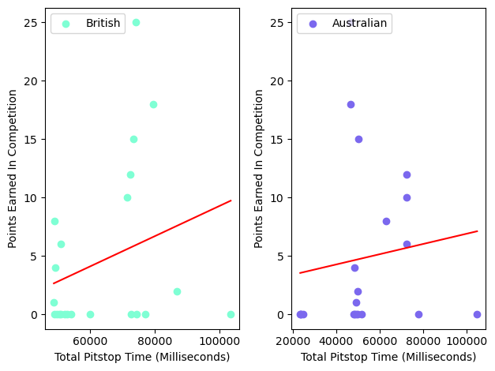

```python
#British Grand Prix
plt.subplot(1, 2, 1)
plt.scatter(x='total_pitstop_duration', y='total_points', data=pitstopduration_agg_British, color = "aquamarine")
plt.xlabel("Total Pitstop Time (Milliseconds)")
plt.ylabel("Points Earned In Competition")
plt.legend(["British"], loc='upper left')
x = pitstopduration_agg_British['total_pitstop_duration']
y = pitstopduration_agg_British['total_points']
m, b = np.polyfit(x, y, 1)
plt.plot(x, m*x + b, color='red')


#Australian Grand Prix
plt.subplot(1, 2, 2)
plt.scatter(x='total_pitstop_duration', y='total_points', data=pitstopduration_agg_Australian, color = "mediumslateblue")
plt.xlabel("Total Pitstop Time (Milliseconds)")
plt.ylabel("Points Earned In Competition")
x = pitstopduration_agg_Australian['total_pitstop_duration']
y = pitstopduration_agg_Australian['total_points']
m, b = np.polyfit(x, y, 1)
plt.plot(x, m*x + b, color='red')


plt.tight_layout()
plt.legend(["Australian"], loc='upper left')
plt.show()
```

```python
#Regression Analysis

results_univariateBritish = smf.ols(formula = 'total_points ~ total_pitstop_duration',data =pitstopduration_agg_British ).fit(cov_type= "HC1")
print(summary_col(results_univariateBritish,
                  stars = True))

results_univariateAustralian = smf.ols(formula = 'total_points ~ total_pitstop_duration',data =pitstopduration_agg_Australian ).fit(cov_type= "HC1")
print(summary_col(results_univariateAustralian,
                  stars = True))
```

```
===================================
                       total_points
-----------------------------------
Intercept              -3.6769
                       (6.1895)
total_pitstop_duration 0.0001
                       (0.0001)
R-squared              0.0778
R-squared Adj.         0.0317
===================================
Standard errors in parentheses.
* p<.1, ** p<.05, ***p<.01

===================================
                       total_points
-----------------------------------
Intercept              2.5185
                       (3.7983)
total_pitstop_duration 0.0000
                       (0.0001)
R-squared              0.0148
R-squared Adj.         -0.0371
===================================
Standard errors in parentheses.
* p<.1, ** p<.05, ***p<.01
```

## INTRODUCTION

Formula 1 is the highest level of single seat car racing conducted internationally. Each year, there are a multitude of different races called Grand Prix - each race is contested in a different location. Drivers drive a specifically designed race car, typically sponsored by different brands such as Tommy Hilfiger, Monster Energy, and Puma, for example. For the 2023 season, there are over 275 sponsorship programs. There are three parts to each race - practice, qualifying, and the race - which are typically conducted over three days. During practice, drivers get to test their car on the track while gauging the weather and overall environment. In the qualifying round, each driver completes a designated amount of laps around the track on their own - this is to determine seeding. The fastest driver gets to start in the first position, and so on. Lastly, the race is conducted on the final day of the Grand Prix sequence. On race day, drivers get to complete one warm up lap before heading to their starting positions as determined by the qualifying round. When the race starts, drivers have to complete a certain amount of laps which typically equate 305 km. During the race, drivers are allowed to return to their garage in order to fuel up, change their tires, etc. Though pit stops can typically be completed quickly, drivers aim to minimize the amount of pit stops they need to take in order to save valuable time. Points are designated to the drivers in the order that they finish the race, with the first driver receiving the most points. The driver with the most points at the end of the Formula 1 season gets crowned the World Champion.

For this project, we decided that the question we are analyzing would be: What is the relationship between pit stop time duration and race results? Understanding the relationship between the duration of a driver’s pit stop and their overall race results is important because pit stops are a critical part of a team’s overall racing strategy. During a pit stop, a team has the chance to refuel, change tires, and make adjustments to the car. These changes all have the ability to improve a driver’s performance - this consequently increases a driver’s chances of winning. On the contrary, if a pit stop crew addresses the wrong components of the car or, more importantly, takes too long, a significant amount of time can be added to the driver’s race, decreasing the driver’s chances of winning. In a sport where races are won or lost by mere seconds, it is vital that pit stops are used in an efficient manner. Through our analysis of a driver’s overall success - in relation to their pit stop duration - drivers can look to improve their overall strategy when it comes to pit stops. For example, if a driver is seeing a lot of success when their pit stops are around a certain time, then they should opt to maintain their timing; contrastingly, if a driver notices that their success is weaning using their current pit stop timing, they should elect to try a different timing scheme.

When beginning this project, we wanted to make sure that our results would be representative and generalizable. Once we decided on our research question, we decided to look at two of the most popular Grand Prix races because they had the most drivers competing, allowing us to most reliably draw conclusions about the Formula 1 population as a whole. Our objective was to determine the relationship between pitstop duration and race success so we decided to use the pit_stops, results, races, and drivers data sets. From here, we knew that we wanted to compare the results and races for each respective driver so we planned a method to merge these data sets using a common variable. Finally, we thought that a scatter plot would best visualize the results we got because we were comparing the relationship between two variables. Scatter plots are efficient at analyzing bivariate relationships and assessing the strength and direction of the relationship between them. Furthermore, scatterplots expose any outliers that might be influencing the results, so we knew that this would best demonstrate our findings even to someone who is not familiar with Formula 1 or the data sets.

## DATA DESCRIPTION

### Merging Procedures

We merged the sorted pitstops dataset (sorted_pitstops = pitstops dataset sorted by duration of stop) with the Races_british_grandprix(Just the British Grand Prix in the races dataset) on raceId, in order to create a new dataset, pitstops_merge_British, that showed the pitstops specifically for the British Grand Prix races, rather than all the races. These same steps were done to create pitstops_merge_Australian, to respectively get the pitstops for the Australian Grand Prix.

```python
pitstops_merge_British = pd.merge(races_British_grandprix,
                          sorted_pitstops_British,
                          on = "raceId",
                          how = "left")
pitstops_merge_Australian = pd.merge(races_Australian_grandprix,
                          sorted_pitstops_Australian,
                          on = "raceId",
                          how = "left")
```

Another merging procedure was used to merge the Results of the British Grand Prix (results_British_grandprix) , with the pit stops in the British Grand Prix, for the year 2011, (British_grandprix_2011). These were merged on “driverId '' so that the resulting dataset would only contain the results for the driver Id’s contained in British_grandprix_2011. This way we were able to get a dataset that contained the duration of the pit stops, which were in British_grandprix_2011, and the results of these specific drivers (because not all drivers drover in the British Grand prix in 2011), which allowed for us to compare these values. The same was done for results_Australian_grandprix and Australian_grandprix_2011.

```python
pitstops_final_British = pd.merge(results_British_grandprix,British_grandprix_2011, on='driverId')
pitstops_final_Australian = pd.merge(results_Australian_grandprix,Australian_grandprix_2011, on='driverId')
```

### Data Cleaning

For data cleaning, we took the large bulky datasets that we created through merging, and created a new dataset with less columns. We first cleaned up the data by only selecting the columns that were relevant to the question we were researching. The original merged dataset had 41 columns of data, so we filtered out the ones not applicable to our research and selected just 5 columns by writing out each column name in quotations and double brackets as seen below.

```python
pitstops_final2_British = pitstops_final_British[["driverId","points","stop","duration","milliseconds_y"]]
pitstops_final2_Australian = pitstops_final_Australian[["driverId","points","stop","duration","milliseconds_y"]]
```

We also faced the issue of duplicates when we merged our data. If a driver made multiple pit stops during the same race, their driverId appeared twice in the driverId column when we wanted each driverId to be a unique value. Thus, we had to aggregate the data set to eliminate these duplicates. We aggregated statistics from the driverId column and used chaining to complete multiple functions at once. For the first argument we input the desired column name (milliseconds_y) and for the second argument we input the desired function we wanted to execute (sum). This allowed us to compute the sum of the pitstop duration times for each driver so that their Id would only appear once in the driverId column. This also allowed us to see clearly how each driver placed because it eliminated duplicates of the total_points column as well.

```python
pitstopduration_agg_British = (pitstops_final2_British.groupby(["driverId"])
                       .agg(total_pitstop_duration = ('milliseconds_y', 'sum'),
                        total_points =('points', 'mean'))
                        .sort_values(by = 'total_pitstop_duration', ascending = False))
pitstopduration_agg_Australian = (pitstops_final2_Australian.groupby(["driverId"])
                       .agg(total_pitstop_duration = ('milliseconds_y', 'sum'),
                        total_points =('points', 'mean'))
                        .sort_values(by = 'total_pitstop_duration', ascending = False))
```

### Main Columns

pitstopduration_agg_British and pitstopduration_agg_Australian were our final 2 datasets that we used for our conclusions. These datasets contain 2 columns (each), one for total_pitstop_duration and one for total points. The total_pitstop_duration column was created in order to show the total amount of time a driver was stopped for, during a specific race. We created this by adding up the total milliseconds of all of the stops that a particular driver took, because most drivers took more than one stop. This gives a more accurate picture for the analysis, rather than using the times of an individual stop. The total points comes from the results dataset, and shows the points each driver received for that specific race (Australian Grand Prix or British Grand Prix). The total points was a numerical way of measuring the results, with the driver that finished first in the race getting 25 points, the number 2 getting 18, number 3 getting 15, and so on. These values were useful to correlate to the total time stopped, in order to show the relation between the time stopped and the results of the race.